# circlize

2023-08-21

# Introduction

Circlize est un package R qui permet de combiner des graphiques de manières circulaires. Toutes les possibilités du package circlize sont expliquées en détail sur ce site [https://jokergoo.github.io/circlize_book/book/introduction.html].

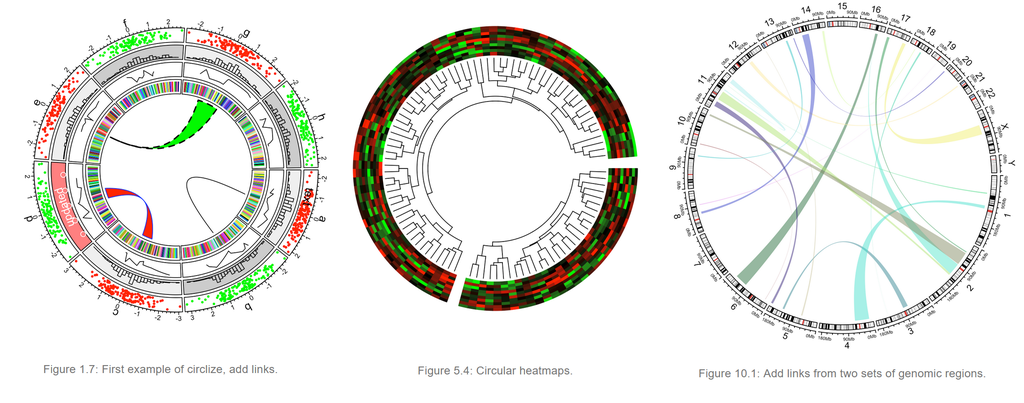

Examples d’utilisation de circlize

## Idées générales

Le cercle est divisé en **secteur (sector)**, qui est défini par une variable catégorielle. Chaque sector sera divisé en plusieurs **circuits (tracks)** concentriques, qui permettent de faire la construction du graphique depuis l’extérieur du cercle vers l’intérieur. Une intersection entre un secteur et un circuit s’appelle une **cellule (cell)**.

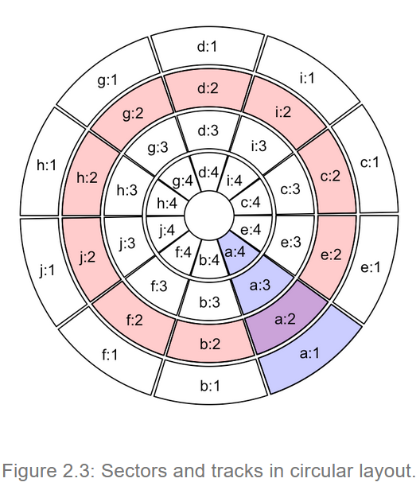

Le package circlize contient différents types de fonction :

- Les fonctions globales, qui régissent la construction générale du cercle
  - `circos.initialize()`
  - `circos.track()`
  - `circos.update()`
  - `circos.par()`
  - `circos.info()`
  - `circos.clear()`
- Les fonctions graphiques dites “bas niveau”
  - `circos.points()`
  - `circos.lines()`
  - `circos.segments()`
  - `circos.rect()`
  - `circos.polygon()`
  - `circos.text()`
  - `circos.axis()` and `circos.yaxis()`
- Les fonctions graphiques dites “haut niveau”
  - `circos.barplot()`
  - `circos.boxplot()`
  - `circos.violin()`
  - `circos.heatmap()`
  - `circos.raster()`
  - `circos.arrow()`
- Les fonctions graphiques de liens entre cellule
  - `circos.link()`

# Tutoriel étape par étape

Le but de ce tutoriel est d’apprendre à comprendre comment fonctionne l’objet `circos`. On va d’abord créer un jeu de données `data` qui va contenir une variable catégorielle `factor` et des données `x` et `y`.

```r
# Upload library
library(circlize)
# Create data
data = data.frame(
    factor = sample(letters[1:8], 1000, replace = TRUE),
    x = rnorm(1000),
    y = runif(1000)
    )
```

La construction du graphique se réalise comme ceci :

1. On initialise le graphique avec `circos.initialize`
2. On fait afficher un circuit avec `circos.track`
3. On construit les graphiques dans les cellules avec les fonctions graphiques
4. Reprendre depuis l’étape 2. jusqu’à la fin du graphique
5. À la fin, on nettoye le graphique avec `circos.clear`

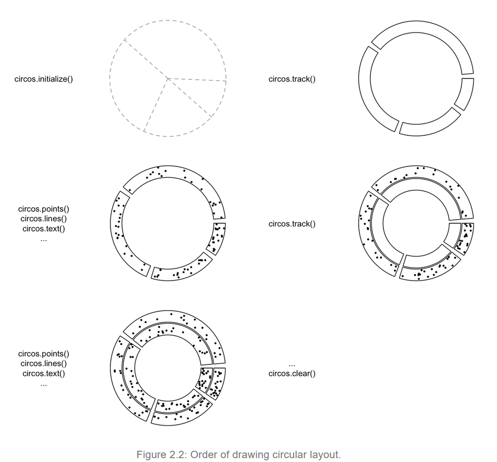

## Initialiser le graphique

L’initialisation du graphique circulaire nécessite 2 variables en entrée :

1. Les catégories des données.
2. La limite de la plage des valeurs de l’axe des abscisses avec`x` ou `xlim`.

```r
circos.initialize( factors=data$factor,
                   x=data$x)
```

```r
circos.clear()
```

L’initialisation ne fait rien afficher, c’est normal ! On vient juste de créer un objet `circos` mais sans avoir fait appel à des fonctions graphiques, l’objet ainsi créer est diviser en sécteurs qui dépendent des catégories qu’on a défini, ici les catégories sont “a”,“b”,“c”,“d”,“e”,“f”,“g”,“h”.

## Tracer un circuit

La fonction qui fait afficher les circuits s’appelle `circos.track`. Elle nécessite 2 entrées

1. Les catégories des données.
2. La limite de la plage des valeurs de l’axe des ordonnées via `y` ou `ylim`.

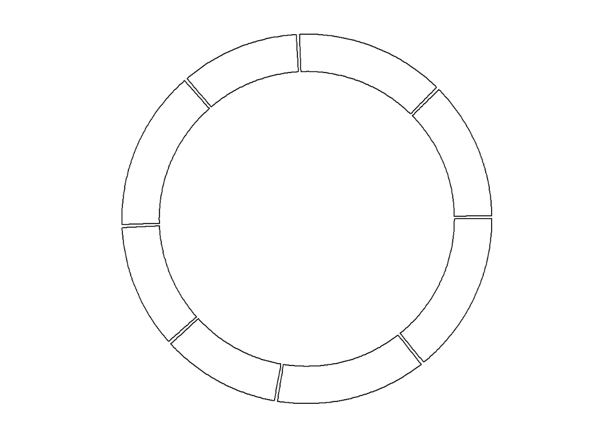

```r
circos.initialize( factors=data$factor,
                   x=data$x)
circos.track(factors = data$factor,
                       y = data$y)
```

```r
circos.clear()
```

On vient de créer notre premier circuit. La fonction `circos.track` peut prendre en entrée d’autre paramètre afin de changer la bordure des régions, le couleur de fond etc.

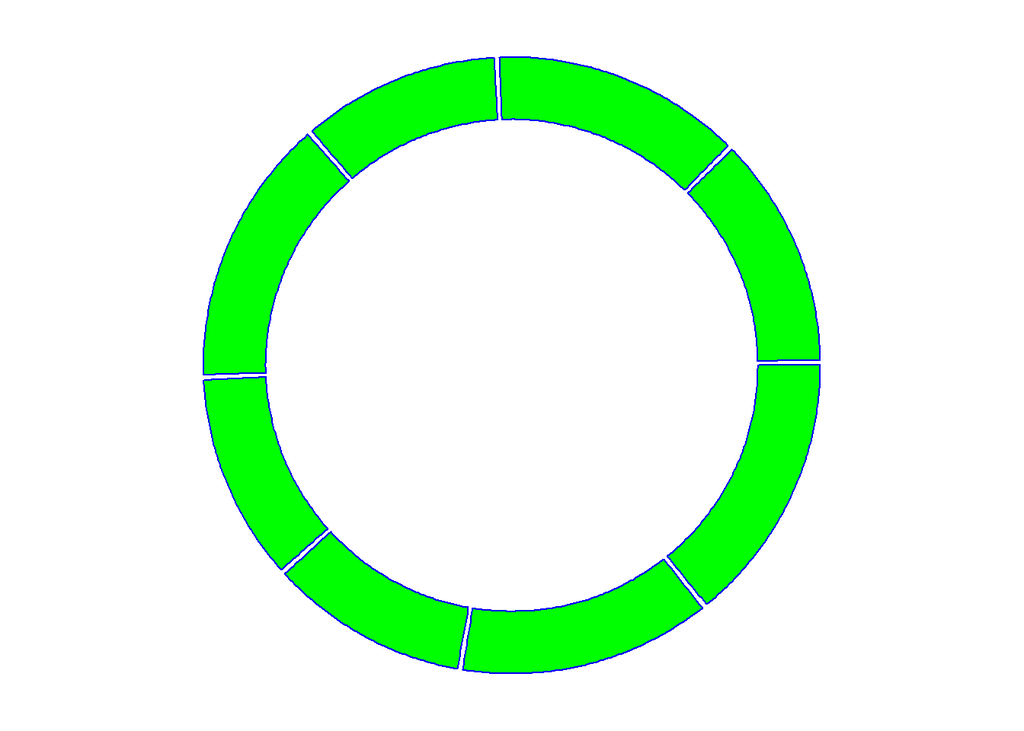

```r
circos.initialize( factors=data$factor,
                   x=data$x)
circos.track(factors = data$factor,
                       y = data$y,
             bg.col = "green",
             bg.border = "blue")
```

```r
circos.clear()
```

En appelant la fonction tracks pluiseurs fois, on créer plusieurs circuits.

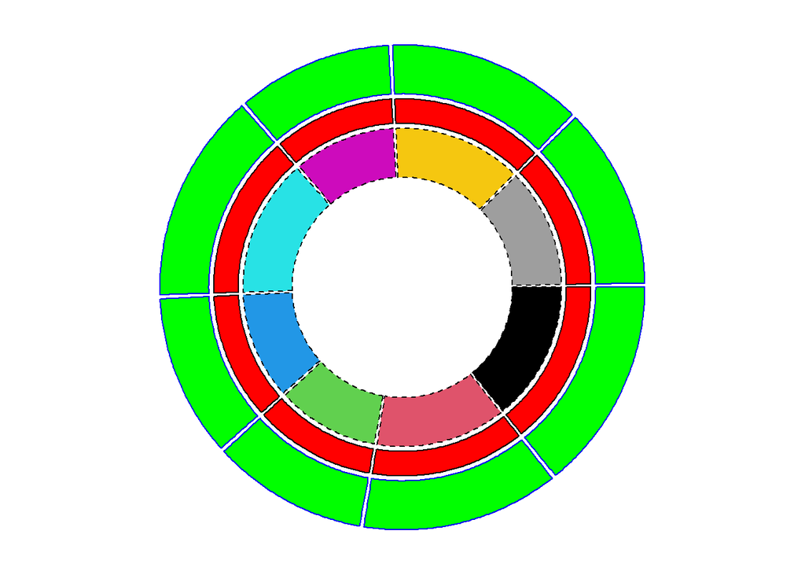

```r
circos.initialize( factors=data$factor,
                   x=data$x)
circos.track(factors = data$factor,
                       y = data$y,
             bg.col = "green",
             bg.border = "blue")
circos.track(factors = data$factor,
                       y = data$y,
             bg.col = "red",
             bg.border = "black",
             track.height = 0.1)
circos.track(factors = data$factor,
                       y = data$y,
             bg.col = 1:8,
             bg.border = "black",
             track.height = 0.2,
             bg.lty = 2)
```

```r
circos.clear()
```

## Tracer les données dans les cellules.

Il est nécessaire de créer un circuit afin d’avoir des cellules (ce circuit peut être invisible/transparent). Une fois les cellules créées, on peut s’en servir pour faire afficher nos graphiques.

Il existe 3 façons différentes de faire tracer les données dans les cellules de l’objet `circos`

1. Tracer les données cellule par cellule
2. Utiliser une des fonctions graphiques comme `circos.trackPoints(),circos.trackLines()`,…
3. Utiliser l’argument `panel.fun` de la fonction ``circos.track`

Il est assez déconseillé d’utiliser la méthode 1. mais pour l’exemple on va quand même le montrer les 3 façons.

### Tracer les données cellule par cellule

Les fonctions qui permettent de tracer des graphiques sur une seule cellule vont le faire par défaut dans la dernière cellule générer par `circos`. Il faut donc préciser dans quel secteur et quel circuit on fait le graphique. Si on veut séparer les données par catégorie , il faudra manuellement le faire au moment du plot.

```r
circos.initialize( factors=data$factor,
                   x=data$x)

circos.track(factors = data$factor,
             y = data$y)



circos.info()
```

```
## All your sectors:
## [1] "a" "b" "c" "d" "e" "f" "g" "h"
##
## All your tracks:
## [1] 1
##
## Your current sector.index is h
## Your current track.index is 1
```

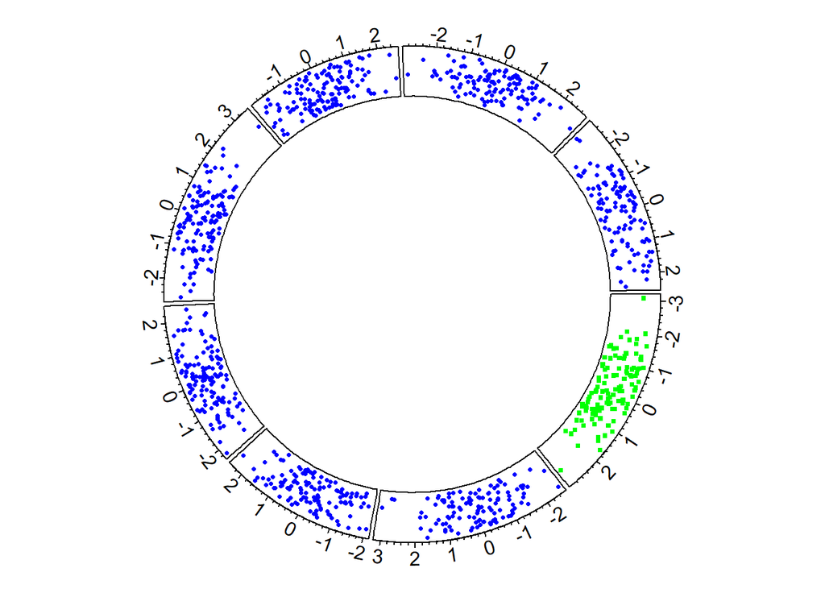

```r
for (j in letters[1:8]){
  circos.points(x=data$x[data$factor==j],
                y=data$y[data$factor==j],
                sector.index = j,
                track.index = 1,
                pch = 16,
                col = "blue",
                cex = 0.5
                ) #fait un scatter plot avec les points (x,y) de la catégorie "j" sur le premier circuit

  circos.axis(sector.index = j,
                track.index = 1,) #fait afficher l'axe des x sur chaque secteur sélectionné


}

circos.update("a",1) #on supprime la cellule "a:1"

 circos.points(x=data$x[data$factor=="a"],
                y=data$y[data$factor=="a"],
                sector.index = "a",
                track.index = 1,
                pch = 15,
                col = "green",
                cex = 0.5
                ) #on la retrace en vert
```

```r
circos.clear()
```

## Utiliser une des fonctions graphiques par circuit

Les fonctions graphiques par circuit sont les fonctions qui commencent par `circos.track...()` comme par exemple `circos.trackHist()`,`circos.trackLines()`,`circos.trackText()` et marchent comme les fonctions de `plot` habituelle. Cependant, si des facteurs sont mis en entrées alors les données seront automatiquement séparé selon les secteurs.

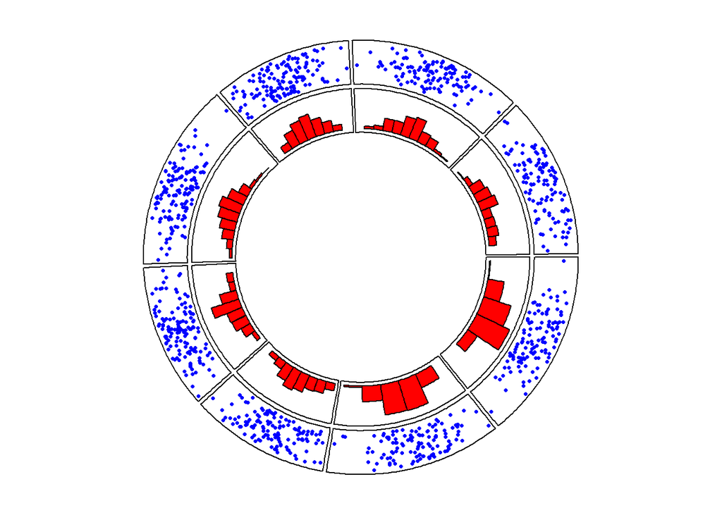

```r
circos.initialize( factors=data$factor,
                   x=data$x)

circos.track(factors = data$factor,
                       y = data$y)

circos.trackPoints(data$factor, data$x, data$y, col = "blue", pch = 16, cex = 0.5)
circos.trackHist(data$factor, data$x,col="red")
```

```r
circos.clear()
```

## 3. Utiliser l’argument `panel.fun` de la fonction `circos.track`

Il s’agit de la méthode conseillée par la documentation du package.

La fonction `circos.track` a comme argument possible `panel.fun` qui demande une fonction de `x,y` et appliquera cette fonction à chaque cellule du circuit, en séparant automatiquement les variables selon les facteurs en entrée.

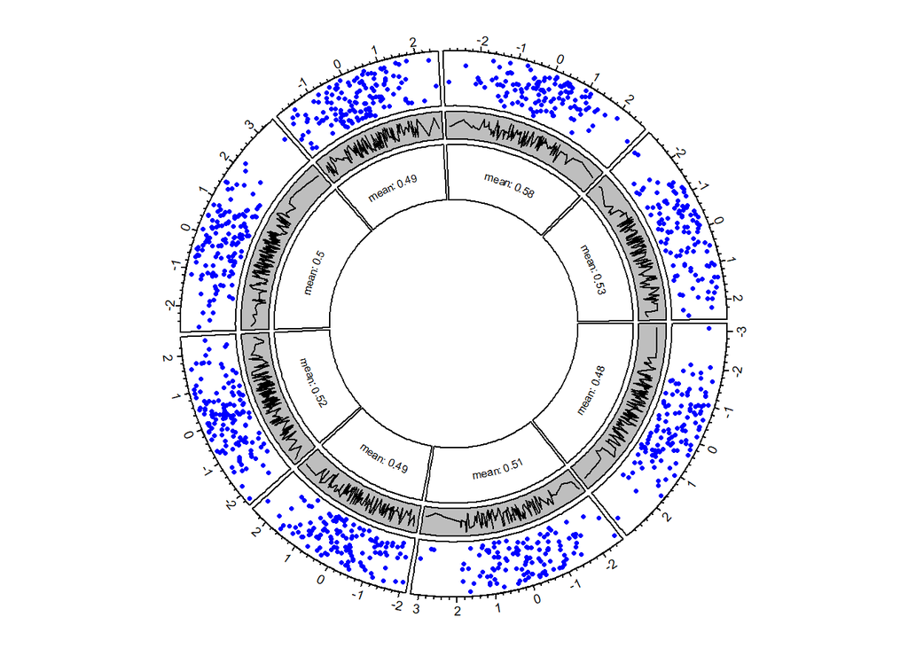

```r
circos.initialize( factors=data$factor,
                   x=data$x)

circos.track(factors = data$factor,
                       x= data$x,
                       y = data$y,
                       panel.fun = function(x,y){
                         circos.axis(labels.cex = 0.6)
                         circos.points(x,y,col = "blue",pch= 16 , cex = 0.5)})

circos.track(factors = data$factor,
             x= data$x,
             y= data$y,
             bg.col = "grey",
             track.height = 0.1,
             panel.fun = function(x,y){
                 or  =order(x)
                 x1 = x[or]
                 y1 = y[or]
                 circos.lines(x1,y1)
             }
             )
 circos.track(factors = data$factor,
             x= data$x,
             y= data$y,
             ylim = c(-1,1),
             track.height = 0.2, panel.fun = function(x,y){
                 meany = mean(y)
                 circos.text(x=0,
                             y=0,
                             paste0("mean: ", round(meany,2)),
                             facing = "bending",
                             niceFacing = TRUE,
                             cex = 0.5)
             })
```

```r
circos.clear()
```

Il est possible d’accéder à des informations au sujet de la cellule directement en utilsant `CELL_META$`

```r
circos.initialize( factors=data$factor,
                   x=data$x)

circos.track(factors = data$factor,
                       x= data$x,
                       y = data$y,
                       panel.fun = function(x,y){
                         circos.axis(labels.cex = 0.6)
                         circos.points(x,y,col = "blue",pch= 16 , cex = 0.5)
             circos.text(CELL_META$xcenter,
            CELL_META$cell.ylim[2] + mm_y(7),
            CELL_META$sector.index,col="red")}
             )
```

```
## Note: 1 point is out of plotting region in sector 'a', track '1'.
```

```
## Note: 1 point is out of plotting region in sector 'b', track '1'.
```

```
## Note: 1 point is out of plotting region in sector 'c', track '1'.
```

```
## Note: 1 point is out of plotting region in sector 'd', track '1'.
```

```
## Note: 1 point is out of plotting region in sector 'e', track '1'.
```

```
## Note: 1 point is out of plotting region in sector 'f', track '1'.
```

```
## Note: 1 point is out of plotting region in sector 'g', track '1'.
```

```
## Note: 1 point is out of plotting region in sector 'h', track '1'.
```

[figure not shown]

```r
circos.clear()
```

Vous savez désormais comment fonctionne l’objet `circos` ! Il reste cependant beaucoup de fonctionnalités, qui sont disponibles sur le lien [https://jokergoo.github.io/circlize_book/book/introduction.html].